# Case_Study_1

Tom Gianelle and Shane Weinstock

2/18/2019

# Case Study 1 - Analysis for Company Beer O’Clock

Our goal is to determine how Beer O’Clock’s new product (high ABV and lower IBU) will compare with the competition’s products and if there is a correlation of ABV to IBU and ultimately discovering if that will have an impact on creating target product.

We also would like to determine how this product will fare in some additional states. Please observe the code and descriptions below that outline our processes and procedures given specific market data.

## Discovering How Many Breweries Exist in Each State

```r
## set to lemon_print functions
knit_print.data.frame <- lemon_print

#setwd("~/Documents/SMU/Doing DS/Unit 7")
breweries <- read.csv("Breweries.csv")
beers <- read.csv("Beers.csv")

## How many breweries are present in each state
df.breweryByStateFreq <- Freq(breweries$State)
brewery_count <- df.breweryByStateFreq[ ,1:2]
## column names
col_headings <- c("State", "# of Breweries")
names(brewery_count) <- col_headings
brewery_count
```

```
##    State # of Breweries
## 1     AK              7
## 2     AL              3
## 3     AR              2
## 4     AZ             11
## 5     CA             39
## 6     CO             47
## 7     CT              8
## 8     DC              1
## 9     DE              2
## 10    FL             15
## 11    GA              7
## 12    HI              4
## 13    IA              5
## 14    ID              5
```

[output cut: 37 more lines]

In this code chunk, we discover the frequency of breweries based on the data contained in our Breweries.csv file. The output after having run this computation is seen above.

## Merging the Two Sets of Data

```r
## merge
colnames(beers)[1] <- "Beer Name"
colnames(breweries)[1] <- "Brewery_id"
colnames(breweries)[2] <- "Brewery Name"
merge_files <- merge( x = breweries, y = beers, by = "Brewery_id", all = TRUE)
mergehead <- head(merge_files, n=6)
mergetail <- tail(merge_files, n=6)
# Assigned variables so that we could print them to CSVs for presentation.
mergehead
```

```
##   Brewery_id       Brewery Name        City State     Beer Name Beer_ID
## 1          1 NorthGate Brewing  Minneapolis    MN       Pumpion    2689
## 2          1 NorthGate Brewing  Minneapolis    MN    Stronghold    2688
## 3          1 NorthGate Brewing  Minneapolis    MN   Parapet ESB    2687
## 4          1 NorthGate Brewing  Minneapolis    MN  Get Together    2692
## 5          1 NorthGate Brewing  Minneapolis    MN Maggie's Leap    2691
## 6          1 NorthGate Brewing  Minneapolis    MN    Wall's End    2690
##     ABV IBU                               Style Ounces
## 1 0.060  38                         Pumpkin Ale     16
## 2 0.060  25                     American Porter     16
## 3 0.056  47 Extra Special / Strong Bitter (ESB)     16
## 4 0.045  50                        American IPA     16
## 5 0.049  26                  Milk / Sweet Stout     16
## 6 0.048  19                   English Brown Ale     16
```

```r
mergetail
```

```
##      Brewery_id                  Brewery Name          City State
## 2405        556         Ukiah Brewing Company         Ukiah    CA
## 2406        557       Butternuts Beer and Ale Garrattsville    NY
## 2407        557       Butternuts Beer and Ale Garrattsville    NY
## 2408        557       Butternuts Beer and Ale Garrattsville    NY
## 2409        557       Butternuts Beer and Ale Garrattsville    NY
## 2410        558 Sleeping Lady Brewing Company     Anchorage    AK
##                      Beer Name Beer_ID   ABV IBU                   Style
## 2405             Pilsner Ukiah      98 0.055  NA         German Pilsener
## 2406         Porkslap Pale Ale      49 0.043  NA American Pale Ale (APA)
## 2407           Snapperhead IPA      51 0.068  NA            American IPA
## 2408         Moo Thunder Stout      50 0.049  NA      Milk / Sweet Stout
## 2409  Heinnieweisse Weissebier      52 0.049  NA              Hefeweizen
## 2410 Urban Wilderness Pale Ale      30 0.049  NA        English Pale Ale
##      Ounces
## 2405     12
## 2406     12
## 2407     12
## 2408     12
## 2409     12
## 2410     12
```

By merging these two sets of data by the column “Brewery ID” we are able to draw further analysis on these two related data sets.

## Number of NA’s in Each Column

```r
df <- data.frame(freq.na(merge_files))
col_headings <- c("# of NA", "% of NA")
names(df) <- col_headings
df
```

```
##              # of NA % of NA
## IBU              974      40
## ABV               57       2
## Brewery_id         0       0
## Brewery Name       0       0
## City               0       0
## State              0       0
## Beer Name          0       0
## Beer_ID            0       0
## Style              0       0
## Ounces             0       0
```

While analyzing the data we discovered that there were many missing values which would prevent us from running future tests on the data. We revealed that there were 1005 missing values in IBU (amounting to around 42% of the data) and then 62 missing values in ABV (amounting to 3% of the data).

We later went in and added data to this (effectively updating beers.csv) to include additional data about states of interest, lowering this number of unassigned values from 1005 in IBU to 974 and ABV from 62 to 57. This aided us greatly in our analysis of desired states and existing products. The data was pulled directly from the brewery websites.

## Median Alcohol Content and International Bitterness Unit for Each State.

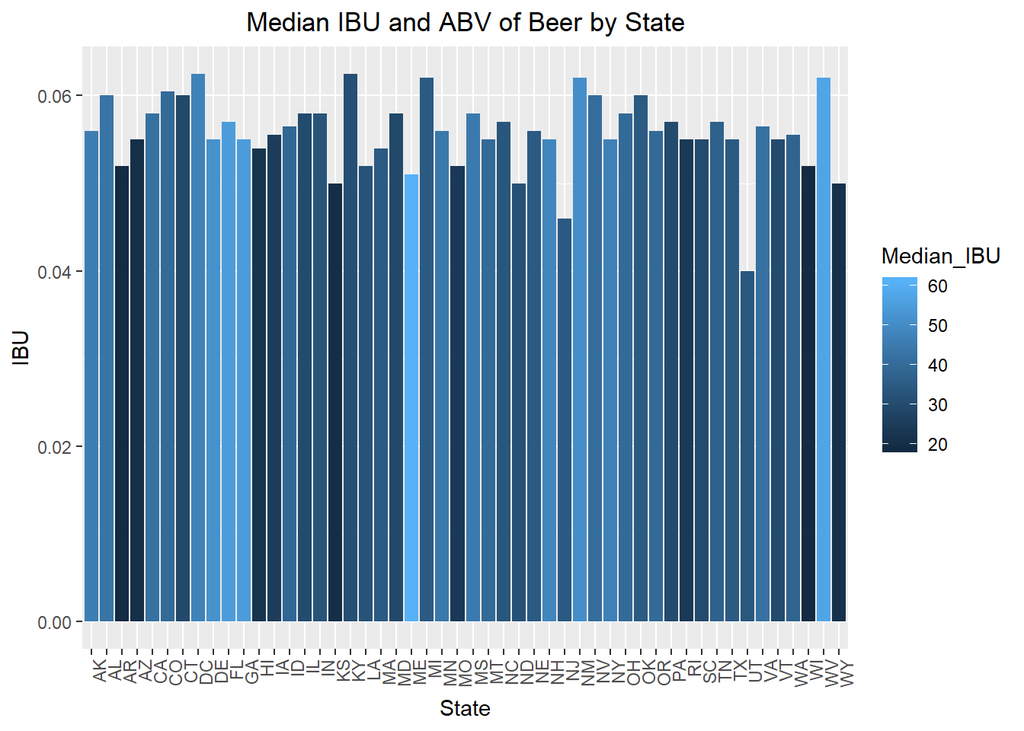

```r
df_abv <- aggregate(merge_files$ABV, list(merge_files$State), median, na.rm = TRUE)
col_headings <- c("State", "Median_ABV")
names(df_abv) <- col_headings

df_ibu <- aggregate(merge_files$IBU, list(merge_files$State), median, na.rm = TRUE)
col_headings <- c("State", "Median_IBU")
names(df_ibu) <- col_headings

merge_bev_analysis <- merge(df_abv, df_ibu, by = "State")
col_headings <- c("State", "Median_ABV", "Median_IBU")
names(merge_bev_analysis) <- col_headings

## median_bev_analysis <- aggregate(merge_files[,c("ABV","IBU")],list(merge_files$State),median,na.rm=TRUE)
## colnames(median_bev_analysis)[1] <- "State"
median_bev_analysis <- merge_bev_analysis[complete.cases(merge_bev_analysis),]
par(las=2)
MedianGraphics_ABV <- ggplot(data = median_bev_analysis, aes(x = State, y = Median_ABV, fill = Median_IBU))+geom_bar(stat = "identity", position="dodge")+labs(title = "Median IBU and ABV of Beer by State", x = "State", y = "IBU")+theme(plot.title = element_text(hjust = 0.5))
MedianGraphics_ABV + theme(axis.text.x = element_text(angle = 90, hjust = 1))
```

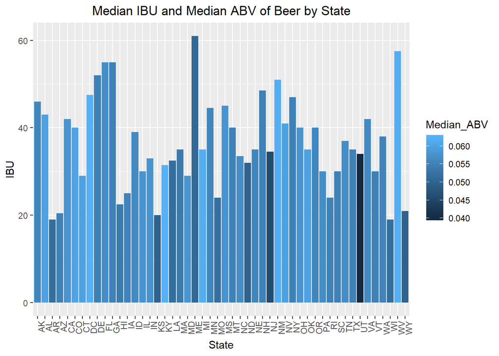

```r
MedianGraphics_IBU <- ggplot(data = median_bev_analysis, aes(x = State, y = Median_IBU, fill = Median_ABV))+geom_bar(stat = "identity", position="dodge")+labs(title = "Median IBU and Median ABV of Beer by State", x = "State", y = "IBU")+theme(plot.title = element_text(hjust = 0.5))
MedianGraphics_IBU + theme(axis.text.x = element_text(angle = 90, hjust = 1))
```

After merging the data sets, we were able to create several comparisons and graphs. In this particular chunk of code, we have two bar graphs of Median IBU and ABV of the Beer by State, helping us further understand the competition we might find as we begin to produce a new beer in any particular state.

## Discovering Which State has the Highest IBU and ABV

```r
merge_files[which.max(merge_files$ABV),]
```

```
##     Brewery_id            Brewery Name    City State
## 384         52 Upslope Brewing Company Boulder    CO
##                                                Beer Name Beer_ID   ABV IBU
## 384 Lee Hill Series Vol. 5 - Belgian Style Quadrupel Ale    2565 0.128  NA
##                Style Ounces
## 384 Quadrupel (Quad)   19.2
```

Boulder, CO produces the highest ABV at 12.8% from brewery Upslope Brewing Company for beer Lee Hill Series Vol. 5 - a Belgian Style Quadrupel Ale.

```r
merge_files[which.max(merge_files$IBU), ]
```

```
##      Brewery_id            Brewery Name    City State
## 1857        375 Astoria Brewing Company Astoria    OR
##                      Beer Name Beer_ID   ABV IBU
## 1857 Bitter Bitch Imperial IPA     980 0.082 138
##                               Style Ounces
## 1857 American Double / Imperial IPA     12
```

Astoria, OR produces the highest IBU at 138 as an American Double/Imperial IPA from Astoria Brewing Company with a beer named the “Bitter Bitch Imperial IPA”.

## Summary statistics for the ABV variable.

```r
summary(beers$ABV, na.rm = TRUE)
```

```
##    Min. 1st Qu.  Median    Mean 3rd Qu.    Max.    NA's
## 0.00100 0.05000 0.05600 0.05978 0.06700 0.12800      57
```

```r
##summary(beers$IBU, na.rm = TRUE)

describe(beers$ABV, na.rm = TRUE)
```

```
## [2410 obs.]
## numeric: 0.05 0.066 0.071 0.09 0.075 0.077 0.045 0.065 0.055 0.086 ...
## min: 0.001 - max: 0.128 - NAs: 57 (2.4%) - 76 unique values
```

```r
## describe(beers$IBU, na.rm = TRUE)

density(beers$ABV,na.rm = TRUE)
```

```
##
## Call:
##  density.default(x = beers$ABV, na.rm = TRUE)
##
## Data: beers$ABV (2353 obs.); Bandwidth 'bw' = 0.002417
##
##        x                   y
##  Min.   :-0.006251   Min.   : 0.0000
##  1st Qu.: 0.029125   1st Qu.: 0.0467
##  Median : 0.064500   Median : 0.6493
##  Mean   : 0.064500   Mean   : 7.0602
##  3rd Qu.: 0.099875   3rd Qu.: 8.2750
##  Max.   : 0.135251   Max.   :40.2483
```

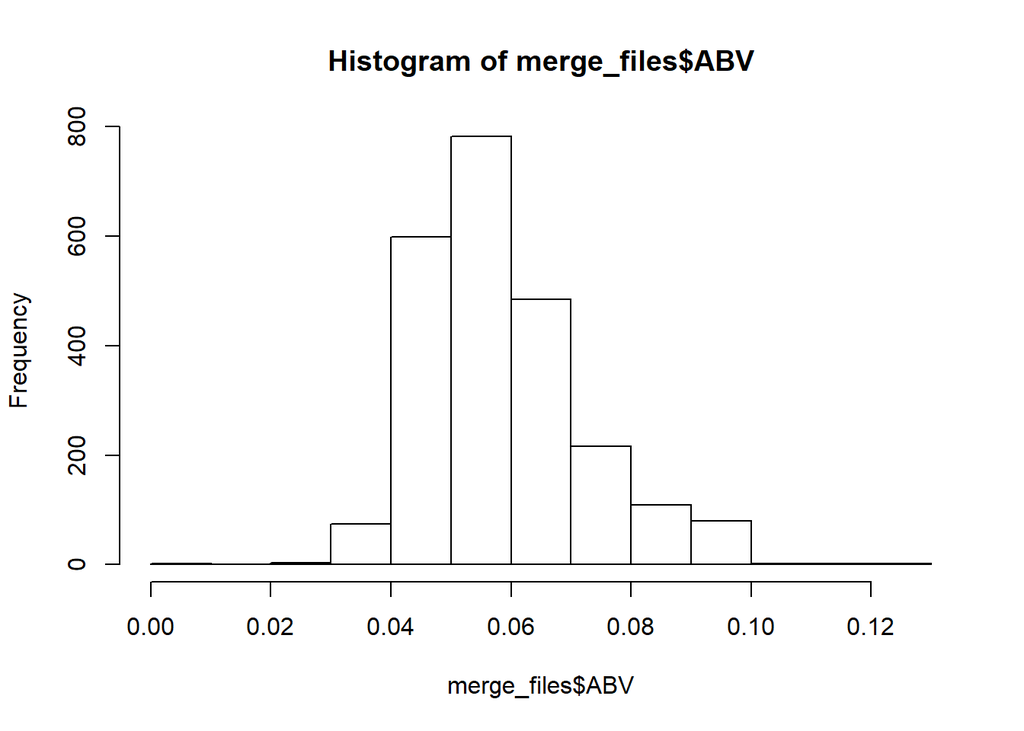

```r
## density(beers$IBU, na.rm = TRUE)

hist(merge_files$ABV)
```

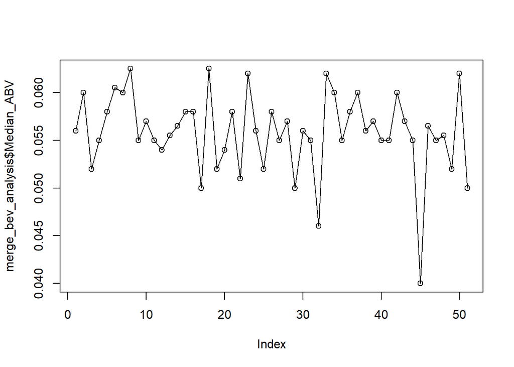

```r
## hist(merge_files$IBU)
plot(merge_bev_analysis$Median_ABV, type = "o")
```

```r
## plot(merge_bev_analysis$Median_IBU, type = "o")
```

In this code chunk we run some basic analysis on the merged data to further compare a future product and it’s placement in the markets we’re evaluating. Additionally, please note that the IBU variable was also evaluated, but as the question does not call for it directly, it has been commented out.

## Correlations and Conclusions

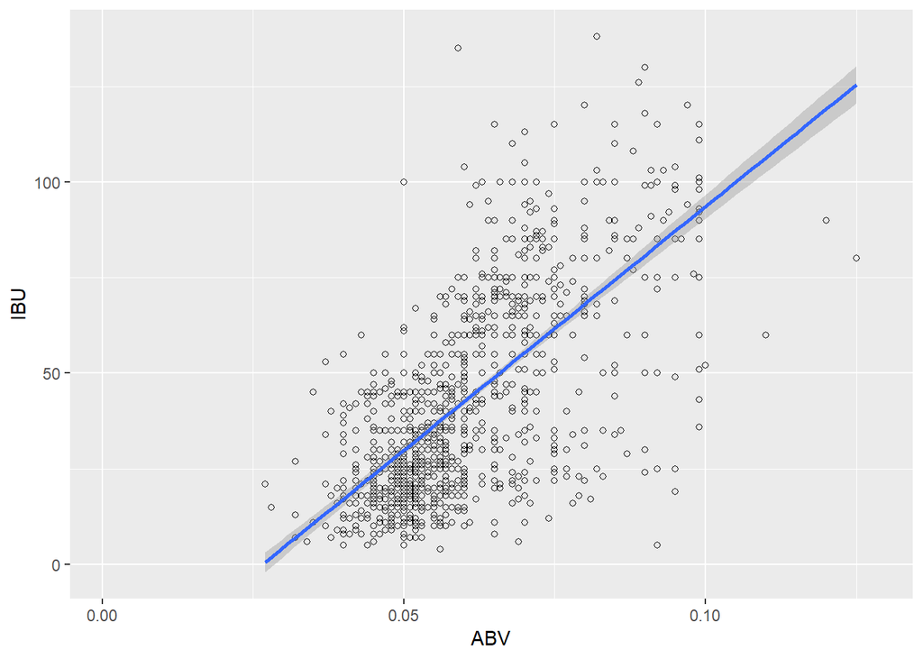

```r
## scatterplots
## require(stats)
## reg<-lm(ABV ~ IBU, data = beers)
## coeff=coefficients(reg)
# equation of the line :
## eq = paste0("y = ", round(coeff[2],1), "*x ", round(coeff[1],1))
# plot
## plot(cars, main=eq)

## plot(beers$ABV, beers$IBU, main=("Scatterplot: ABV vs IBU"), xlab = "ABV", ylab="IBU")
## abline(lm(ABV ~ IBU, data = beers), col="blue")
## plot(df$Median_ABV, df$Median_IBU, main=("ABV vs IBU Scatterplot"), xlab = "ABV", ylab="IBU")
ggsp <- ggplot(data=beers, aes(x=ABV, y=IBU)) +
    geom_point(shape=1)     # Use hollow circles

ggsp + geom_smooth(method=lm)
```

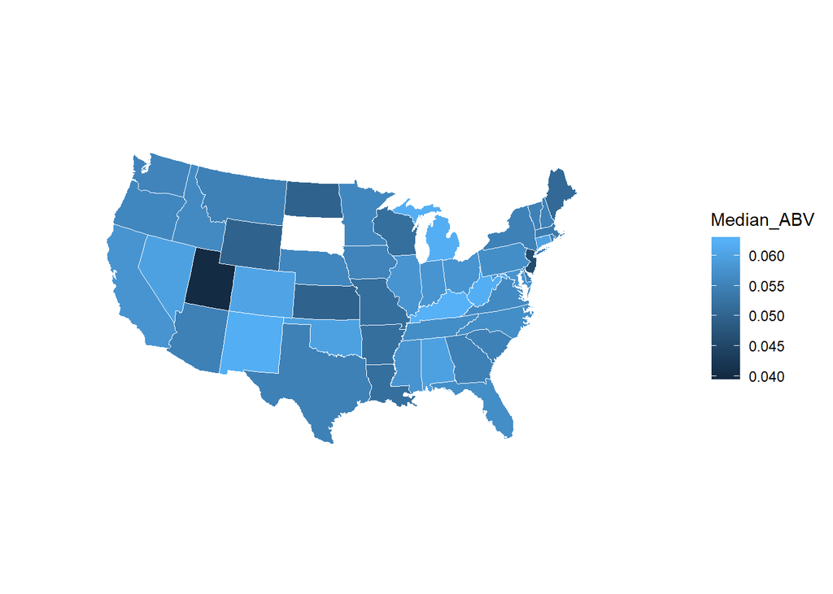

```r
## ggsp + geom_point(shape=1) +    # Use hollow circles
##    geom_smooth()            # Add a loess smoothed fit curve with confidence region
df <- data.frame(merge_bev_analysis)
## plot_usmap(data = df$State, values = "Median_ABV", lines = "blue") +
##  scale_fill_continuous(
##    low = "white", high = "blue", name = "Median ABV", label = scales::comma
##  ) + theme(legend.position = "right")

us <- map_data("state")
median_bev_state <- data.frame(abbr2state(trimws(as.character(median_bev_analysis$State), "l")), median_bev_analysis$Median_ABV, median_bev_analysis$Median_IBU)
col_headings <- c("region", "Median_ABV", "Median_IBU")
names(median_bev_state) <- col_headings
arr <- median_bev_state %>%
##   add_rownames("region") %>%
mutate(region=tolower(region))
## arr <- arr[,-1]

gg <- ggplot()
gg <- gg + geom_map(data=us, map=us,
                    aes(x=long, y=lat, map_id=region),
                    fill="#ffffff", color="#ffffff", size=0.15)
gg <- gg + geom_map(data=arr, map=us,
                    aes(fill=Median_ABV, map_id=region),
                    color="#ffffff", size=0.15)
gg <- gg + labs(x=NULL, y=NULL)
gg <- gg + coord_map("albers", lat0 = 39, lat1 = 45)
gg <- gg + theme(panel.border = element_blank())
gg <- gg + theme(panel.background = element_blank())
gg <- gg + theme(axis.ticks = element_blank())
gg <- gg + theme(axis.text = element_blank())
gg
```

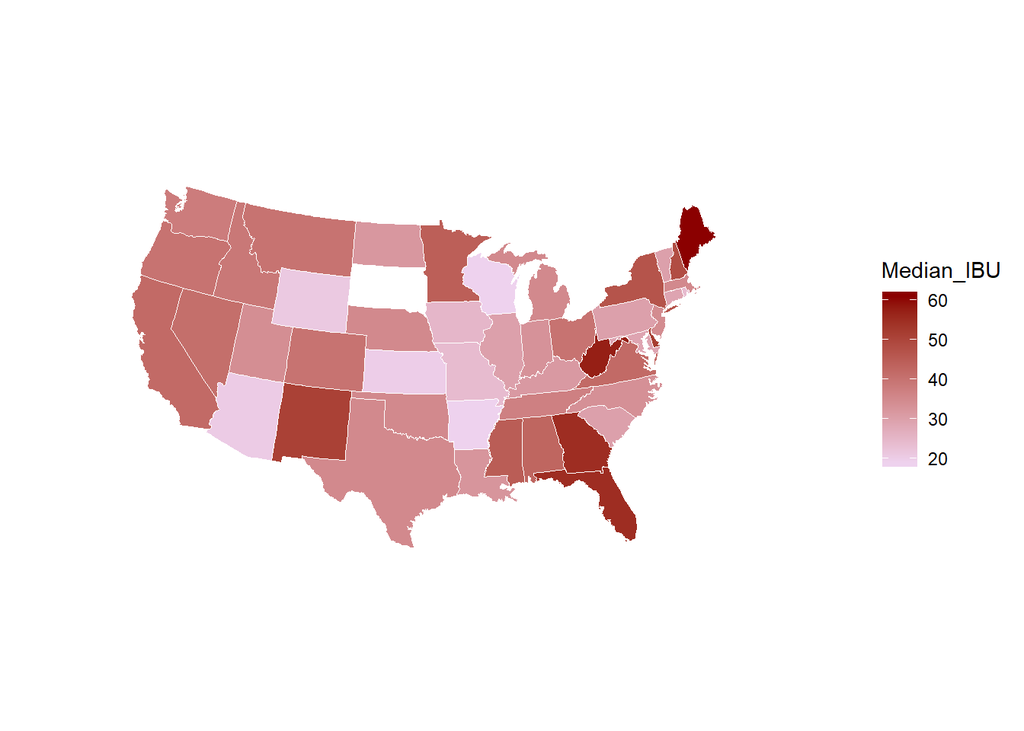

```r
gg <- ggplot()
gg <- gg + geom_map(data=us, map=us,
                    aes(x=long, y=lat, map_id=region),
                    fill="#ffffff", color="#ffffff", size=0.15)
gg <- gg + geom_map(data=arr, map=us,
                    aes(fill=Median_IBU, map_id=region),
                    color="#ffffff", size=0.15)
gg <- gg + scale_fill_continuous(low='thistle2', high='darkred',
                                 guide='colorbar')
gg <- gg + labs(x=NULL, y=NULL)
gg <- gg + coord_map("albers", lat0 = 39, lat1 = 45)
gg <- gg + theme(panel.border = element_blank())
gg <- gg + theme(panel.background = element_blank())
gg <- gg + theme(axis.ticks = element_blank())
gg <- gg + theme(axis.text = element_blank())
gg
```

### Conclusions

Based on the data that is provided, we can conclude that: